# Differential Expression Analysis in *Syngnathus fuscus*

Coley Tosto

2023-10-23

```r
#The abundance matrix generated via salmon and tximport to be used for the DE analysis
FU_txi.salmon <- readRDS("data/txi.salmon_FU.RDS")

#The samples file generated for tximport
FU_samples <- read.table("FU_samples.txt", header = TRUE)

#Make sure the conditions are in the samples file as a factor
FU_samples$Sex <- as.factor(FU_samples$Sex)
FU_samples$Organ <- as.factor(FU_samples$Organ)
```

The package `DESeq2` was used for the differential expression analysis outlined below.

# 1 Single factor analysis - Comparing Males v Females

To analyze your data with DESeq2 you must first generate the DESeqDataSet. In order to do this we need the abundance matrix generated with `tximport` and a `samples` file that lays out all of the conditions.

```r
#Create the DESeq dataset
dds_FU <- DESeqDataSetFromTximport(FU_txi.salmon,
                                   colData = FU_samples,
                                   design = ~ Sex)
```

The data is then pre-filtered to remove low gene counts before running further DESeq2 functions. By doing this we remove rows in which there are very few reads thus reducing the memory size of the `dds` object and increasing the speed at which we can use the transformation and testing functions in DESeq2.

```r
#only keeping rows that have at lead 10 reads total
keep <- rowSums(counts(dds_FU)) >= 10
dds_FU <- dds_FU[keep, ]
```

After filtering we can now perform the standard differential expression analysis that is wrapped into DESeq2.

```r
#Generate the expression values
dds_FU_exp <- DESeq(dds_FU)

#Compile the results
res <- results(dds_FU_exp)
res
```

```
## log2 fold change (MLE): Sex M vs F
## Wald test p-value: Sex M vs F
## DataFrame with 193637 rows and 6 columns
##                         baseMean log2FoldChange     lfcSE       stat    pvalue
##                        <numeric>      <numeric> <numeric>  <numeric> <numeric>
## TRINITY_DN0_c0_g1     1224.15627     -0.7105364  0.255547 -2.7804536 0.0054283
## TRINITY_DN0_c1_g1     4528.38058     -0.4239128  0.297621 -1.4243368 0.1543490
## TRINITY_DN0_c10_g1     552.52273     -0.0126323  0.182706 -0.0691402 0.9448780
## TRINITY_DN0_c11_g1      28.55379      0.7130072  0.506622  1.4073758 0.1593160
## TRINITY_DN0_c125_g1      2.62197      0.2234249  0.820431  0.2723262 0.7853712
## ...                          ...            ...       ...        ...       ...
## TRINITY_DN99991_c0_g1   0.644610       1.419240  1.615112   0.878725  0.379550
## TRINITY_DN99993_c0_g1   2.586928       0.660824  0.812081   0.813741  0.415793
## TRINITY_DN99995_c0_g1   0.361104       0.996595  2.973076   0.335206  0.737469
## TRINITY_DN99997_c0_g1   1.841278      -0.990609  1.293794  -0.765662  0.443878
## TRINITY_DN99999_c0_g1   0.452691      -2.016813  2.530238  -0.797084  0.425402
##                            padj
##                       <numeric>
## TRINITY_DN0_c0_g1      0.059560
## TRINITY_DN0_c1_g1      0.460392
## TRINITY_DN0_c10_g1     0.987621
## TRINITY_DN0_c11_g1     0.468337
## TRINITY_DN0_c125_g1    0.943650
## ...                         ...
## TRINITY_DN99991_c0_g1        NA
## TRINITY_DN99993_c0_g1  0.752957
## TRINITY_DN99995_c0_g1        NA
## TRINITY_DN99997_c0_g1  0.775208
## TRINITY_DN99999_c0_g1        NA
```

Once that has finished we can now start exploring some of the single-factor analysis results

```r
##Ordering our results based on p-value
resOrdered <- res[order(res$pvalue),]
resOrdered
```

```
## log2 fold change (MLE): Sex M vs F
## Wald test p-value: Sex M vs F
## DataFrame with 193637 rows and 6 columns
##                        baseMean log2FoldChange     lfcSE      stat      pvalue
##                       <numeric>      <numeric> <numeric> <numeric>   <numeric>
## TRINITY_DN22310_c0_g1  804.2311        27.6241   1.89885   14.5477 6.03588e-48
## TRINITY_DN13824_c0_g1   92.1347        25.5625   1.92144   13.3039 2.19823e-40
## TRINITY_DN35004_c1_g2  129.5764        26.0372   2.10520   12.3680 3.89194e-35
## TRINITY_DN34941_c0_g1  260.2356        27.0195   2.24241   12.0493 1.95581e-33
## TRINITY_DN9279_c0_g1    23.3464        23.3498   1.95493   11.9441 6.97254e-33
## ...                         ...            ...       ...       ...         ...
## TRINITY_DN99935_c0_g1         0              0         0         0           1
## TRINITY_DN99938_c0_g1         0              0         0         0           1
## TRINITY_DN99956_c0_g1         0              0         0         0           1
## TRINITY_DN99961_c0_g1         0              0         0         0           1
## TRINITY_DN99973_c0_g1         0              0         0         0           1
##                              padj
##                         <numeric>
## TRINITY_DN22310_c0_g1 3.82524e-43
## TRINITY_DN13824_c0_g1 6.96563e-36
## TRINITY_DN35004_c1_g2 8.22172e-31
## TRINITY_DN34941_c0_g1 3.09873e-29
## TRINITY_DN9279_c0_g1  8.83769e-29
## ...                           ...
## TRINITY_DN99935_c0_g1          NA
## TRINITY_DN99938_c0_g1          NA
## TRINITY_DN99956_c0_g1          NA
## TRINITY_DN99961_c0_g1          NA
## TRINITY_DN99973_c0_g1          NA
```

```r
summary(res)
```

```
##
## out of 174116 with nonzero total read count
## adjusted p-value < 0.1
## LFC > 0 (up)       : 4003, 2.3%
## LFC < 0 (down)     : 3581, 2.1%
## outliers [1]       : 0, 0%
## low counts [2]     : 130262, 75%
## (mean count < 1)
## [1] see 'cooksCutoff' argument of ?results
## [2] see 'independentFiltering' argument of ?results
```

```r
#How many ADJUSTED p-values were less than 0.1?
sum(res$padj < 0.1, na.rm = TRUE)
```

```
## [1] 7584
```

```r
#Looking at  an alpha=0.05, the default is 0.1
res05 <- results(dds_FU_exp, alpha = 0.05)
summary(res05)
```

```
##
## out of 174116 with nonzero total read count
## adjusted p-value < 0.05
## LFC > 0 (up)       : 2626, 1.5%
## LFC < 0 (down)     : 2488, 1.4%
## outliers [1]       : 0, 0%
## low counts [2]     : 123551, 71%
## (mean count < 1)
## [1] see 'cooksCutoff' argument of ?results
## [2] see 'independentFiltering' argument of ?results
```

```r
sum(res05$padj < 0.05, na.rm = TRUE)
```

```
## [1] 5114
```

Looking at the summary of our results we can see that there are 2,626 male-biased genes and 2,488 female-biased genes when all of the organs are organized together. While this is informative, I am more interested in a multi-factor approach that takes into account both Sex and Tissue type. Before the multi-factor analysis, we can visualize some results from the single-factor analysis and use it for exploratory data analysis.

## 1.1 Visualizing the results

### MA-plot - MvF Diff.

Generate an MA-plot to show the log2 fold changes attributable to sex over the mean of normalized counts for all of the samples in the `dds`. Points will be colored if the adjusted p-value is less that 0.05.

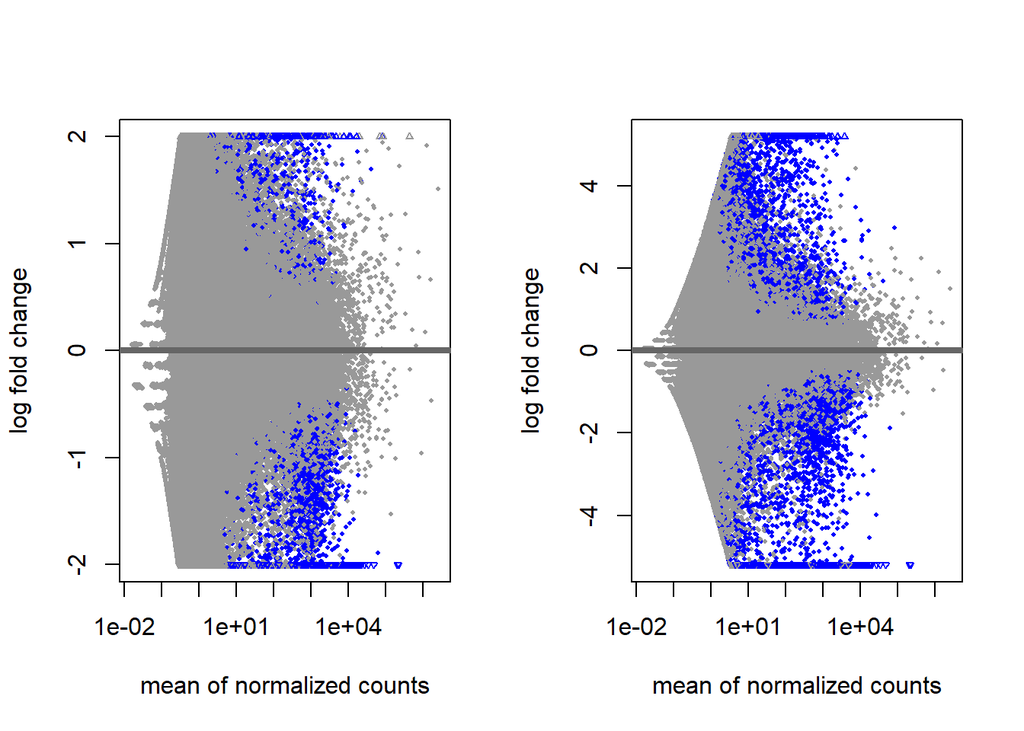

### Heatmap - overall expression

We can also generate a heat map to look ar overall expression levels across our samples. Note, this is not differentially expressed genes.

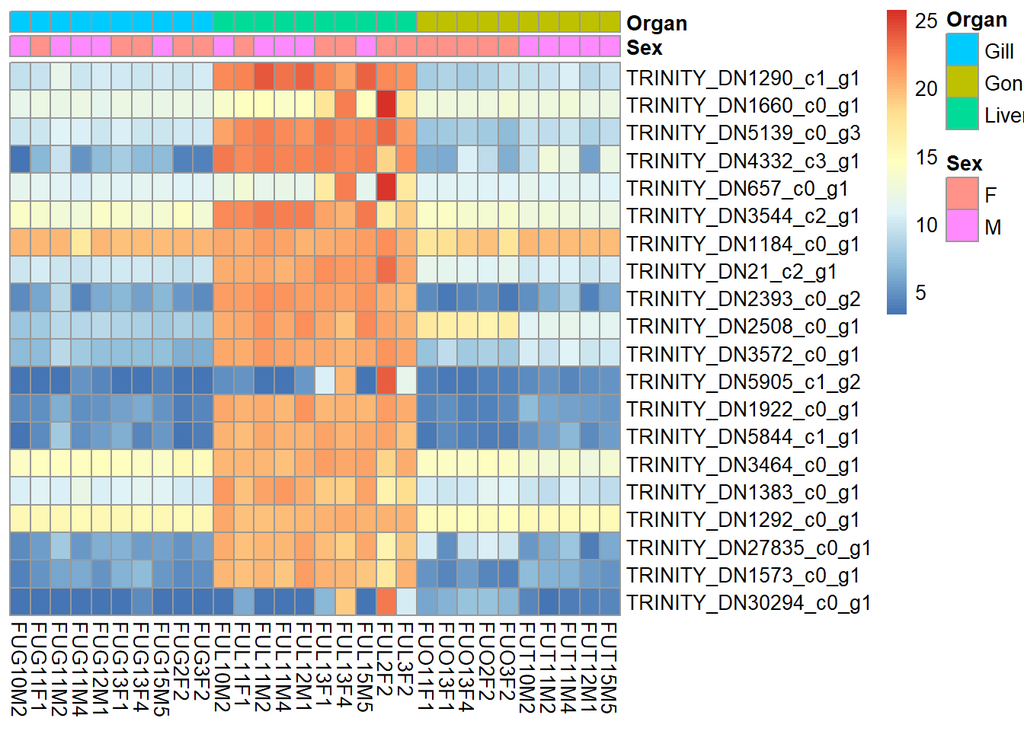

From the heatmap we can pull out the names of the Trinity genes that are showing this high expression and BLAST the corresponding sequences to see what the genes are.

```r
#Pull out the corresponding trinity_geneIDS that are plotted in the heatmap
heatmap_TG <- cbind(row.names(assay(vsd)[select,]))

#Only run once to create the file and then commented out
#write.table(heatmap_TG,
            #'FU_heatmap_trinitygenes.txt',
            #sep = "",
            #quote=FALSE,
            #row.names = FALSE,
            #col.names = FALSE)
```

### Sample-dist Heatmap

We can then generate a sample-to-sample distances heatmap that will give an overview of the similarities and differences between our samples

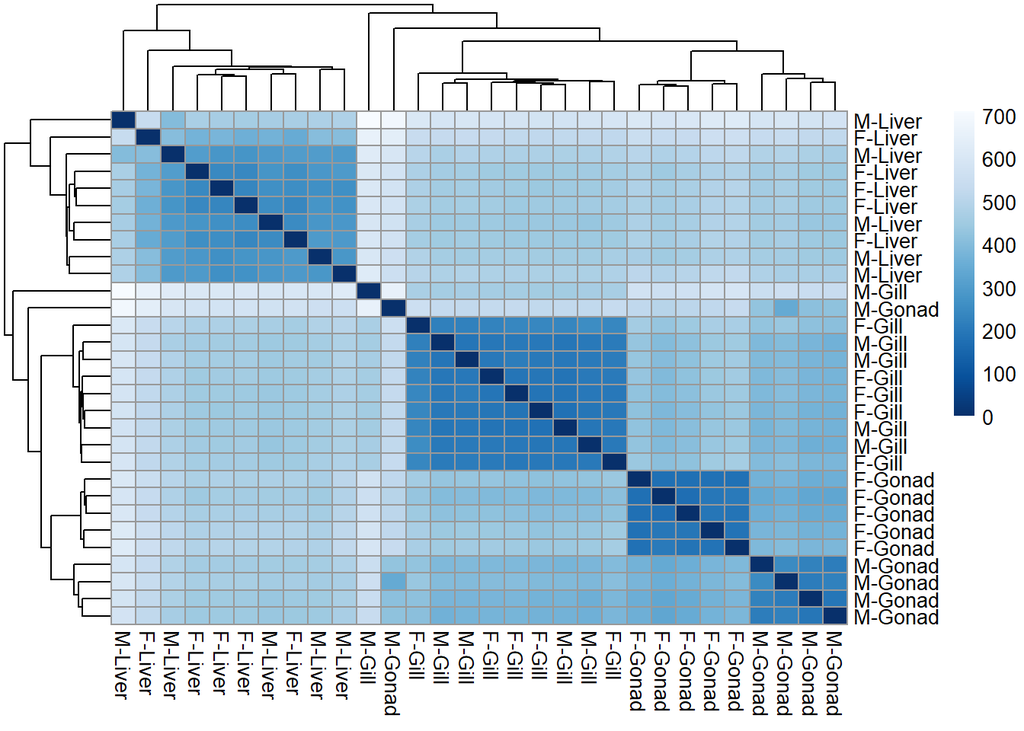

### PCA plots

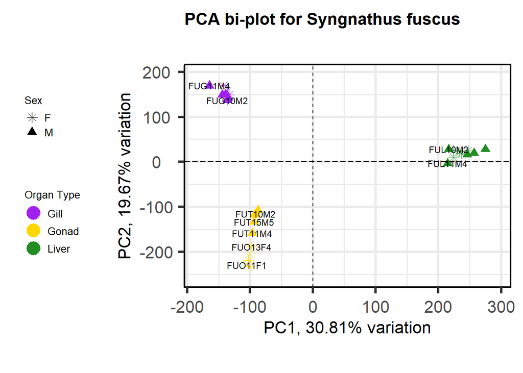

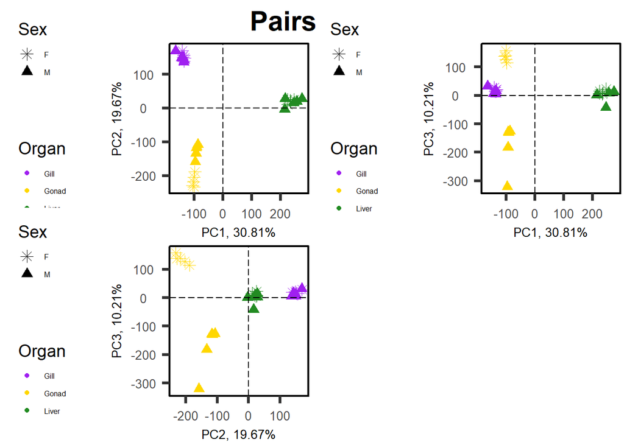

# 2 Multifactor design - Comparing M v F across the diff tissue types

If we investigate the column data of our DESeq dataset we can see that each sample has both a sex and organ type attached to it, we will be using these two factors in our multi-factor analysis

```r
##Create a copy of the DESeq dataset
ddsMF_FU <- dds_FU

#Create an additional column the has the two conditions combined(sex and organ type)
ddsMF_FU$group <- factor(paste0(ddsMF_FU$Sex, ddsMF_FU$Organ))

#Reapply that new column as the design for this analysis
design(ddsMF_FU) <- ~ group

#Run the differential expression analysis
ddsMF_FU_exp <- DESeq(ddsMF_FU)
resultsNames(ddsMF_FU_exp)
```

```
## [1] "Intercept"             "group_FGonad_vs_FGill" "group_FLiver_vs_FGill"
## [4] "group_MGill_vs_FGill"  "group_MGonad_vs_FGill" "group_MLiver_vs_FGill"
```

## 2.1 Invesitgate the results of the differential expression

Thanks to the multi-factor analysis we can now explore differential expression between all of the different combinations of tissues and sexes:

- Male Liver v. Female Liver
- Male Gill v. Female Gill
- Male Gonad v. Female Gonad
- All of the within sex tissue comparisons (e.g. Male Liver v. Male Gill, etc.)

### M-F Liver Comparisson

```r
##Pulling out the liver M-F results with an alpha of 0.05
FU_liver_con_res <- results(ddsMF_FU_exp, contrast = c("group", "MLiver", "FLiver"), alpha = 0.05)
FU_liver_con_res$trin_geneid <- rownames(FU_liver_con_res)
head(FU_liver_con_res)
```

```
## log2 fold change (MLE): group MLiver vs FLiver
## Wald test p-value: group MLiver vs FLiver
## DataFrame with 6 rows and 7 columns
##                       baseMean log2FoldChange     lfcSE      stat     pvalue
##                      <numeric>      <numeric> <numeric> <numeric>  <numeric>
## TRINITY_DN0_c0_g1   1224.15627      -0.920292  0.296285 -3.106109 0.00189567
## TRINITY_DN0_c1_g1   4528.38058       0.186998  0.239493  0.780807 0.43491599
## TRINITY_DN0_c10_g1   552.52273       0.150381  0.307384  0.489227 0.62468067
## TRINITY_DN0_c11_g1    28.55379       0.705499  0.773121  0.912533 0.36148808
## TRINITY_DN0_c125_g1    2.62197      -1.307570  1.516224 -0.862386 0.38847516
## TRINITY_DN0_c13_g1    22.93125       0.892307  0.840381  1.061788 0.28833215
##                          padj         trin_geneid
##                     <numeric>         <character>
## TRINITY_DN0_c0_g1   0.0164538   TRINITY_DN0_c0_g1
## TRINITY_DN0_c1_g1   0.7397187   TRINITY_DN0_c1_g1
## TRINITY_DN0_c10_g1  0.8852638  TRINITY_DN0_c10_g1
## TRINITY_DN0_c11_g1  0.6728350  TRINITY_DN0_c11_g1
## TRINITY_DN0_c125_g1        NA TRINITY_DN0_c125_g1
## TRINITY_DN0_c13_g1  0.5940164  TRINITY_DN0_c13_g1
```

```r
summary(FU_liver_con_res)
```

```
##
## out of 193637 with nonzero total read count
## adjusted p-value < 0.05
## LFC > 0 (up)       : 4117, 2.1%
## LFC < 0 (down)     : 1648, 0.85%
## outliers [1]       : 19700, 10%
## low counts [2]     : 134593, 70%
## (mean count < 5)
## [1] see 'cooksCutoff' argument of ?results
## [2] see 'independentFiltering' argument of ?results
```

I will be classifying sex-biased genes the same way that I did for *Syngnathus floridae* as **genes with a p-value < 0.05 AND a logFC $\ge$ |2|**. With that criteria in the liver there are 3433 male-biased genes and 531 female-biased genes.

I have then pulled out all of the male-biased, female-biased, and non-biased genes based on the criteria outlined above. I determined non-biased genes as a p-vaule > 0.05.

```r
#Removing the rows where padj. is NA in results
FU_liver_con_res_noNA <- FU_liver_con_res[!is.na(FU_liver_con_res$padj),]
summary(FU_liver_con_res_noNA) #We can now see that there are no outliers or low counts since the NAs have been removed
```

```
##
## out of 39344 with nonzero total read count
## adjusted p-value < 0.05
## LFC > 0 (up)       : 4117, 10%
## LFC < 0 (down)     : 1648, 4.2%
## outliers [1]       : 0, 0%
## low counts [2]     : 0, 0%
## (mean count < 5)
## [1] see 'cooksCutoff' argument of ?results
## [2] see 'independentFiltering' argument of ?results
```

```r
#Creating a vector that contains all of the male-biased and female-biased genes in the liver
FU_liver_mal_biased <- FU_liver_con_res_noNA[which(FU_liver_con_res_noNA$log2FoldChange >= 2 & FU_liver_con_res_noNA$padj <= 0.05),]
FU_liver_fem_biased <- FU_liver_con_res_noNA[which(FU_liver_con_res_noNA$log2FoldChange <= -2 & FU_liver_con_res_noNA$padj <= 0.05),]

#Creating an object that contains all of the non-biased genes in the liver
FU_liver_non_biased <- FU_liver_con_res_noNA[which(FU_liver_con_res_noNA$padj > 0.05),]
```

I will be generating a table that outlines the genes that are the most male or female biased in each organ type. To do this I need to pull the top 50 differentially expressed genes in males or females, get the Trinity gene IDs and then BLAST the corresponding sequences. Here I am pulling out the Trinity gene IDs for those genes.

```r
#Creating a subset of the results where the p-value is less than 0.05
FU_liver_con_res_p05 <- FU_liver_con_res_noNA[FU_liver_con_res_noNA$padj <= 0.05, ]


#Pulling the top 50 diff expressed genes in Males
top50_FU_MLiver <- head(FU_liver_con_res_p05[order(FU_liver_con_res_p05$log2FoldChange, decreasing = TRUE), ], n = 50)
#Run once to generate the file and then commented out
#write.table(cbind(rownames(top50_FU_MLiver)),
 #           'FU_maleL_top50TRgenes.txt',
 #            sep = "",
 #           quote=FALSE,
 #           row.names = FALSE,
 #           col.names = FALSE)


#Pulling the top 50 diff expressed genes in Females
top50_FU_Fliver <- head(FU_liver_con_res_p05[order(FU_liver_con_res_p05$log2FoldChange, decreasing = FALSE), ], n = 50)
#Run once to generate the file and then commented out
#write.table(cbind(rownames(top50_FU_Fliver)),
 #           'FU_femL_top50TRgenes.txt',
 #            sep = "",
 #           quote=FALSE,
 #           row.names = FALSE,
 #           col.names = FALSE)
```

### M-F Gill Comparisson

```r
##Pulling out the gill M-F results
gill_con_res_FU <- results(ddsMF_FU_exp, contrast = c("group", "MGill", "FGill"), alpha = 0.5)
gill_con_res_FU$trin_geneid <- rownames(gill_con_res_FU)
head(gill_con_res_FU)
```

```
## log2 fold change (MLE): group MGill vs FGill
## Wald test p-value: group MGill vs FGill
## DataFrame with 6 rows and 7 columns
##                       baseMean log2FoldChange     lfcSE       stat    pvalue
##                      <numeric>      <numeric> <numeric>  <numeric> <numeric>
## TRINITY_DN0_c0_g1   1224.15627     -0.2451242  0.294971 -0.8310103  0.405968
## TRINITY_DN0_c1_g1   4528.38058      0.0271107  0.239205  0.1133367  0.909764
## TRINITY_DN0_c10_g1   552.52273     -0.1016038  0.301096 -0.3374459  0.735781
## TRINITY_DN0_c11_g1    28.55379      0.2116800  0.750828  0.2819289  0.777998
## TRINITY_DN0_c125_g1    2.62197      0.3003708  1.186438  0.2531704  0.800137
## TRINITY_DN0_c13_g1    22.93125     -0.0555559  0.774685 -0.0717141  0.942829
##                          padj         trin_geneid
##                     <numeric>         <character>
## TRINITY_DN0_c0_g1           1   TRINITY_DN0_c0_g1
## TRINITY_DN0_c1_g1           1   TRINITY_DN0_c1_g1
## TRINITY_DN0_c10_g1          1  TRINITY_DN0_c10_g1
## TRINITY_DN0_c11_g1          1  TRINITY_DN0_c11_g1
## TRINITY_DN0_c125_g1        NA TRINITY_DN0_c125_g1
## TRINITY_DN0_c13_g1          1  TRINITY_DN0_c13_g1
```

```r
summary(gill_con_res_FU)
```

```
##
## out of 193637 with nonzero total read count
## adjusted p-value < 0.5
## LFC > 0 (up)       : 1065, 0.55%
## LFC < 0 (down)     : 256, 0.13%
## outliers [1]       : 19700, 10%
## low counts [2]     : 125912, 65%
## (mean count < 3)
## [1] see 'cooksCutoff' argument of ?results
## [2] see 'independentFiltering' argument of ?results
```

In the gills there were 95 genes that we can consider male-biased and 32 female-biased genes based on our criteria for sex-bias.

I have then pulled out all of the male-biased, female-biased, and non-biased genes to save them into their own objects.

```r
#Removing the rows where padj. is NA in results
FU_gill_con_res_noNA <- gill_con_res_FU[!is.na(gill_con_res_FU$padj), ]
summary(FU_gill_con_res_noNA) #We can now see that there are no outliers or low counts since the NAs have been removed
```

```
##
## out of 48025 with nonzero total read count
## adjusted p-value < 0.5
## LFC > 0 (up)       : 1065, 2.2%
## LFC < 0 (down)     : 256, 0.53%
## outliers [1]       : 0, 0%
## low counts [2]     : 0, 0%
## (mean count < 3)
## [1] see 'cooksCutoff' argument of ?results
## [2] see 'independentFiltering' argument of ?results
```

```r
#Creating a vector that contains all of the male-biased and female-biased genes in the gills
FU_gill_mal_biased <- FU_gill_con_res_noNA[which(FU_gill_con_res_noNA$log2FoldChange >= 2 & FU_gill_con_res_noNA$padj <= 0.05),]
FU_gill_fem_biased <- FU_gill_con_res_noNA[which(FU_gill_con_res_noNA$log2FoldChange <= -2 & FU_gill_con_res_noNA$padj <= 0.05),]

#Creating an object that contains all of the non-biased genes in the gills, p>0.05
FU_gill_non_biased <- FU_gill_con_res_noNA[which(FU_gill_con_res_noNA$padj > 0.05),]
```

Here I am getting the trinity gene IDs that correspond to the top 50 differentially expressed genes for males and females.

```r
#Creating a subset of results where p-value is less than 0.05
FU_gill_con_res_p05 <- FU_gill_con_res_noNA[FU_gill_con_res_noNA$padj <= 0.05,]

#Pulling the top 50 diff expressed genes in Males
top50_FU_MGill <- head(FU_gill_con_res_p05[order(FU_gill_con_res_p05$log2FoldChange, decreasing = TRUE),], n=50)
#Run once to generate the file and then commented out
#write.table(cbind(rownames(top50_FU_MGill)),
 #           'FU_maleG_top50TRgenes.txt',
 #           sep = "",
 #           quote=FALSE,
 #           row.names = FALSE,
 #           col.names = FALSE)

#Pulling the top 50 diff expressed genes in Females
top50_FU_FGill <- head(FU_gill_con_res_p05[order(FU_gill_con_res_p05$log2FoldChange, decreasing = FALSE),], n=50)
#Run once to generate the file and then commented out
#write.table(cbind(rownames(top50_FU_FGill)),
 #           'FU_femG_top50TRgenes.txt',
 #           sep = "",
 #           quote=FALSE,
 #           row.names = FALSE,
 #           col.names = FALSE)
```

### M-F Gonad Comparisson

```r
##Pulling out the gonad M-F results
gonad_con_res_FU <- results(ddsMF_FU_exp, contrast = c("group", "MGonad", "FGonad"), alpha = 0.05)
gonad_con_res_FU$trin_geneid <- rownames(gonad_con_res_FU)
head(gonad_con_res_FU)
```

```
## log2 fold change (MLE): group MGonad vs FGonad
## Wald test p-value: group MGonad vs FGonad
## DataFrame with 6 rows and 7 columns
##                       baseMean log2FoldChange     lfcSE      stat      pvalue
##                      <numeric>      <numeric> <numeric> <numeric>   <numeric>
## TRINITY_DN0_c0_g1   1224.15627     -0.8430009  0.295167 -2.856013 4.28998e-03
## TRINITY_DN0_c1_g1   4528.38058     -1.3031542  0.238906 -5.454672 4.90633e-08
## TRINITY_DN0_c10_g1   552.52273     -0.0507497  0.301102 -0.168546 8.66153e-01
## TRINITY_DN0_c11_g1    28.55379      1.6974644  0.770391  2.203380 2.75680e-02
## TRINITY_DN0_c125_g1    2.62197      3.8117660  1.497842  2.544839 1.09328e-02
## TRINITY_DN0_c13_g1    22.93125     -2.0263586  0.781751 -2.592077 9.53985e-03
##                            padj         trin_geneid
##                       <numeric>         <character>
## TRINITY_DN0_c0_g1   1.66430e-02   TRINITY_DN0_c0_g1
## TRINITY_DN0_c1_g1   5.83140e-07   TRINITY_DN0_c1_g1
## TRINITY_DN0_c10_g1  1.00000e+00  TRINITY_DN0_c10_g1
## TRINITY_DN0_c11_g1  7.67099e-02  TRINITY_DN0_c11_g1
## TRINITY_DN0_c125_g1 3.62691e-02 TRINITY_DN0_c125_g1
## TRINITY_DN0_c13_g1  3.23512e-02  TRINITY_DN0_c13_g1
```

```r
summary(gonad_con_res_FU)
```

```
##
## out of 193637 with nonzero total read count
## adjusted p-value < 0.05
## LFC > 0 (up)       : 13802, 7.1%
## LFC < 0 (down)     : 7275, 3.8%
## outliers [1]       : 19700, 10%
## low counts [2]     : 108769, 56%
## (mean count < 2)
## [1] see 'cooksCutoff' argument of ?results
## [2] see 'independentFiltering' argument of ?results
```

Between the ovaries and testis (gonads) there were 10308 genes that we can consider male-biased and 3801 female-biased genes based on our criteria for sex-bias.

From the gonad M-F results I have then pulled out all of the male-biased, female-biased, and non-biased genes and saved them to their own objects.

```r
#Removing the rows where padj. is NA in results
FU_gonad_con_res_noNA <- gonad_con_res_FU[!is.na(gonad_con_res_FU$padj), ]
summary(FU_gonad_con_res_noNA) #We can now see that there are no outliers or low counts since the NAs have been removed
```

```
##
## out of 65168 with nonzero total read count
## adjusted p-value < 0.05
## LFC > 0 (up)       : 13802, 21%
## LFC < 0 (down)     : 7275, 11%
## outliers [1]       : 0, 0%
## low counts [2]     : 0, 0%
## (mean count < 2)
## [1] see 'cooksCutoff' argument of ?results
## [2] see 'independentFiltering' argument of ?results
```

```r
#Creating an object that contains all of the male-biased and female-biased genes in the gonads
FU_gonad_mal_biased <- FU_gonad_con_res_noNA[which(FU_gonad_con_res_noNA$log2FoldChange >= 2 & FU_gonad_con_res_noNA$padj <= 0.05),]
FU_gonad_fem_biased <- FU_gonad_con_res_noNA[which(FU_gonad_con_res_noNA$log2FoldChange <= -2 & FU_gonad_con_res_noNA$padj <= 0.05),]

#Creating an object that contains all of the non-biased genes in the gonads, p>0.05
FU_gonad_non_biased <- FU_gonad_con_res_noNA[which(FU_gonad_con_res_noNA$padj > 0.05),]
```

I then pulled out the trinity gene IDs that corresponded to the top 50 differentially expressed genes in males and females so that I could BLAST the sequences.

```r
#Creating a subset of the results where the p-value is less than 0.05
FU_gonad_con_res_p05 <- FU_gonad_con_res_noNA[FU_gonad_con_res_noNA$padj <= 0.05,]

#Pulling the top 50 diff expressed genes in Males
top50_FU_MGonad <- head(FU_gonad_con_res_p05[order(FU_gonad_con_res_p05$log2FoldChange, decreasing = TRUE),], n=50)
#Run once to generate the file and then commented out
#write.table(cbind(rownames(top50_FU_MGonad)),
 #           'FU_maleGon_top50TRgenes.txt',
 #           sep = "",
 #           quote=FALSE,
 #           row.names = FALSE,
 #           col.names = FALSE)

#Pulling the top 50 diff expressed genes in Females
top50_FU_FGonad <- head(FU_gonad_con_res_p05[order(FU_gonad_con_res_p05$log2FoldChange, decreasing = FALSE),], n=50)
#Run once to generate the file and then commented out
#write.table(cbind(head(top50_FU_FGonad)),
 #           'FU_femGon_top50TRgenes.txt',
 #           sep = "",
 #           quote=FALSE,
 #           row.names = FALSE,
 #           col.names = FALSE)
```

### MA Plots

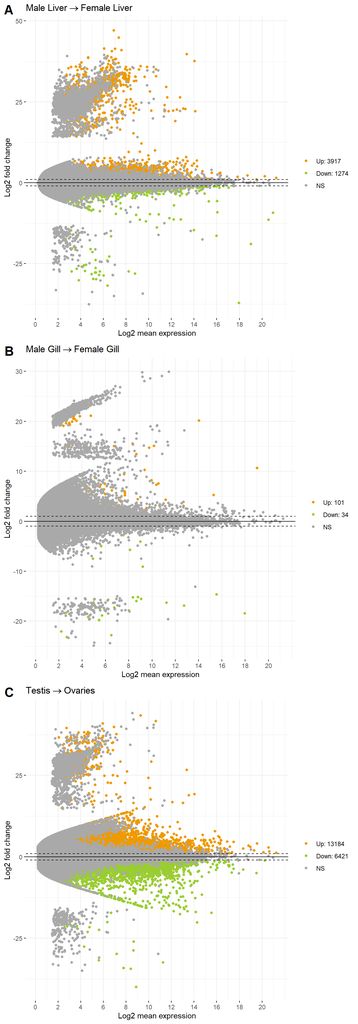

## 2.2 Creating an Upset Plot

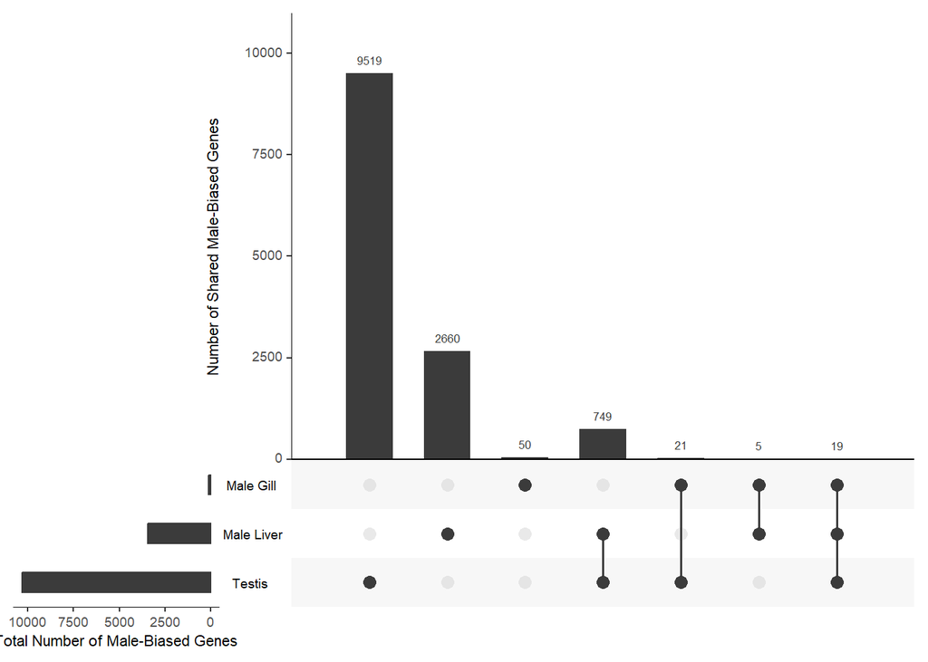

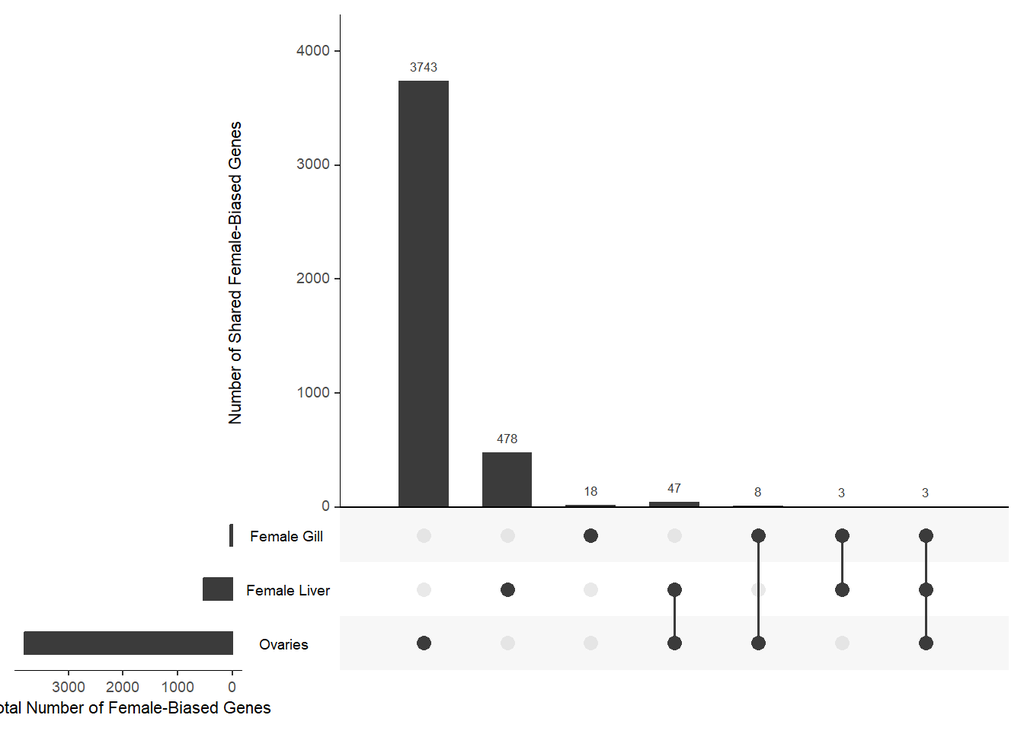

## 2.3 Variation in FC across sex-bias and tissue type

I want to create a plot the highlights the variation we see in fold-change both across the different biases groups (male-biased, female-biased, and non-biased) within one tissue type and across all of the tissue types. To do this I first need to create a “long” dataset in the following format:

| Tissue_type | Bias | Fold-Change |
| --- | --- | --- |
| Gill | male_bias | XXXXX |
| Gill | male_bias | XXXXX |
| Gill | fem_bias | XXXXX |
| Gill | no_bias | XXXXX |
| … | …. | … |
| Liver | male_bias | XXXXX |
| Liver | male_bias | XXXXX |
| Liver | fem_bias | XXXXX |
| Liver | no_bias | XXXXX |
| … | …. | … |
| Gonad | male_bias | XXXXX |
| Gonad | male_bias | XXXXX |
| Gonad | fem_bias | XXXXX |
| Gonad | no_bias | XXXXX |
| … | …. | … |

That dataset is created here, with the Trinity gene IDs included as well:

```r
FU_logFC_long<- data.frame(
  tissue=c(rep("Gill",nrow(FU_gill_fem_biased)),
           rep("Gill", nrow(FU_gill_mal_biased)),
           rep("Gill", nrow(FU_gill_non_biased)),
           rep("Gonad", nrow(FU_gonad_fem_biased)),
           rep("Gonad", nrow(FU_gonad_mal_biased)),
           rep("Gonad", nrow(FU_gonad_non_biased)),
           rep("Liver", nrow(FU_liver_fem_biased)),
           rep("Liver", nrow(FU_liver_mal_biased)),
           rep("Liver", nrow(FU_liver_non_biased))
         ),
  bias=c(rep("FB",nrow(FU_gill_fem_biased)),
         rep("MB",nrow(FU_gill_mal_biased)),
         rep("NB", nrow(FU_gill_non_biased)),
         rep("FB", nrow(FU_gonad_fem_biased)),
         rep("MB", nrow(FU_gonad_mal_biased)),
         rep("NB", nrow(FU_gonad_non_biased)),
         rep("FB", nrow(FU_liver_fem_biased)),
         rep("MB", nrow(FU_liver_mal_biased)),
         rep("NB", nrow(FU_liver_non_biased))
         ),
  logFC=c(FU_gill_fem_biased$log2FoldChange,
          FU_gill_mal_biased$log2FoldChange,
          FU_gill_non_biased$log2FoldChange,
          FU_gonad_fem_biased$log2FoldChange,
          FU_gonad_mal_biased$log2FoldChange,
          FU_gonad_non_biased$log2FoldChange,
          FU_liver_fem_biased$log2FoldChange,
          FU_liver_mal_biased$log2FoldChange,
          FU_liver_non_biased$log2FoldChange
          ),
  geneID=c(rownames(FU_gill_fem_biased),
           rownames(FU_gill_mal_biased),
           rownames(FU_gill_non_biased),
           rownames(FU_gonad_fem_biased),
           rownames(FU_gonad_mal_biased),
           rownames(FU_gonad_non_biased),
           rownames(FU_liver_fem_biased),
           rownames(FU_liver_mal_biased),
           rownames(FU_liver_non_biased)
           )

)
```

With the dataset in the proper format now, we can generate the plot

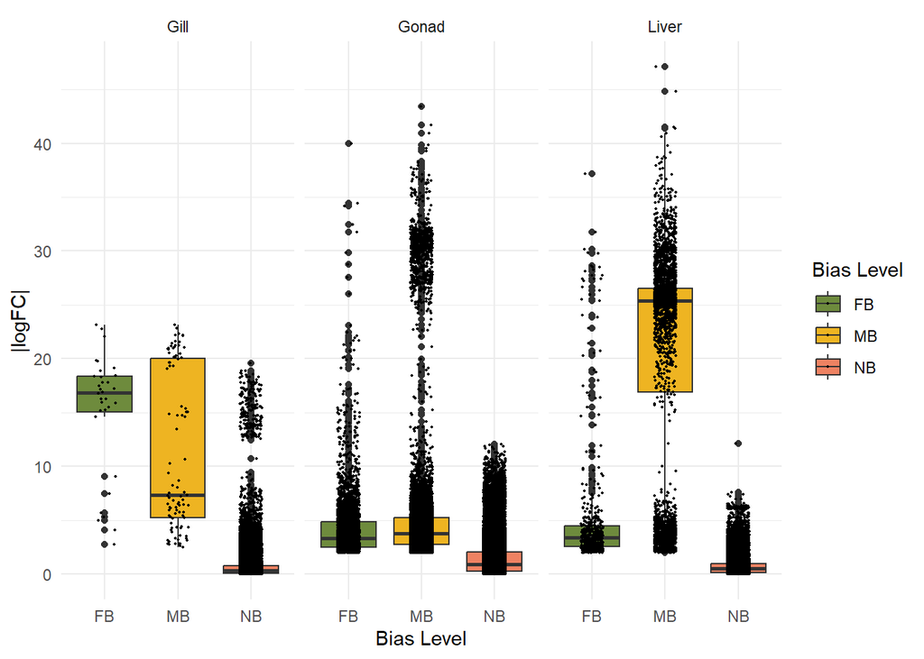

## 2.4 Categorizing sex-specific genes

Now that we have investigated what the sex-bias is like across the different tissue types I want to dive further into genes with **sex-specific expression**. These are genes expressed only in one sex or the other. I am classifying a sex-specific genes within each tissue as ones where the expression of that gene is 0 for all of one sex and there is a median of $\ge 10$ in the other sex.

```r
#Create a vector with the different organ types
organs <- levels(colData(dds_FU)$Organ)

#Create an empty list to store my datasets in
FU_sex_specific_genes <- list()

#Generate the for loop to identify MSpecific and FSpecific genes in each organ based on Medians
for(organ in organs){

  #Male-Specific Genes
  ##Pull out all of the rows where fem count = 0
  fem0_organ <- assay(dds_FU)[rowSums(assay(dds_FU)[, dds_FU$Sex == "F" & dds_FU$Organ==organ]) < 1, dds_FU$Organ == organ]

  ##Pull out rows where median of male count >=10 for that organ
  mal10_organ <- apply(assay(dds_FU)[, dds_FU$Sex == "M" & dds_FU$Organ == organ],
                       1,
                       function(x) median(x) >=10)

  ##Keep only the rows where fem=0 and the Male median>=10
  fem0_mal10_organ <- fem0_organ[rownames(fem0_organ) %in% names(mal10_organ[mal10_organ == TRUE]),]

  ##Create a new object with a name based on the organ type
  organ_malsp <- sub("$", "_male_specific", organ)
  FU_sex_specific_genes[[organ_malsp]] <- fem0_mal10_organ



  #Female-Specific Genes
  ##Pull out all of the rows where male count = 0
  mal0_organ <- assay(dds_FU)[rowSums(assay(dds_FU)[, dds_FU$Sex == "M" & dds_FU$Organ==organ]) < 1, dds_FU$Organ == organ]

  ##Pull out rows where median of female count >=10 for that organ
  fem10_organ <- apply(assay(dds_FU)[, dds_FU$Sex == "F" & dds_FU$Organ == organ],
                       1,
                       function(x) median(x) >=10)

  #Keep only the rows where male=0 and the fem median>=10
  mal0_fem10_organ <- mal0_organ[rownames(mal0_organ) %in% names(fem10_organ[fem10_organ == TRUE]),]

  # Create a new object with a name based on the organ type
  organ_femsp <- sub("$", "_female_specific", organ)
  FU_sex_specific_genes[[organ_femsp]] <- mal0_fem10_organ
}
```

### 2.4.1 Investigating the results of the sex-specific subsetting

Let’s now take a look at how many sex-specific genes we have in each tissue type:

Sex-specific Genes

| Tissue Type | Sex | Number of Sex-specific Genes |
| --- | --- | --- |
| Gill | F | 8 |
| Gill | M | 16 |
| Gonad | F | 320 |
| Gonad | M | 955 |
| Liver | F | 7 |
| Liver | M | 7 |

To get a better idea what is going on between the sex-specific genes vs the sex-biased genes I first determined how many overlaps there were between our sex-biased and sex-specific genes and then used plotCounts to plot the counts for each gene separately.

In the **Male Gills** there are 1 genes that overlap between sex-biased and sex-specific, there are 499 overlapping in the **gonads** and 5 overlapping in the **liver**. For females we have 1 overlapping sex-specific and sex-biased genes in the **gills**, 150 genes in the **gonads**, and 5 genes in the **liver**.